# Lab-05-PECK

April Peck

11/14/2021

```r
library(pander)
library(stargazer)
library(here)
library(dplyr)
library(tidycensus)
library(magrittr)
library(scales)

import::here("%>%",
             "S_TYPE",
             "d",
             "df",
             "d3",
             "l3",
             "PLOTS",
             # notice the use of here::here() that points to the .R file
             # where all these R objects are created
             .from = here::here("analysis/utilities_master.R"),
             .character_only = TRUE)
```

# Overview of Programs

#### About the New Market Tax Credits Program

The NMTC Program enables economically distressed communities to leverage private investment capital by providing investors with a federal tax credit. All NMTC investments must meet statutory qualifications for their investors to be able to claim the tax credit. The vast majority of NMTC investments are made within statutorily defined “Low-Income Communities.” Low-Income Communities are census tracts with a poverty rate of 20 percent or greater, or a median family income at or below 80 percent of the applicable area median family income. In addition to investments located in Low-Income Communities, investments can qualify for NMTCs by using other statutory provisions designed to target certain areas or populations, including provisions for Rural Counties, and Low-Income Targeted Populations.

Through the first 15 application rounds of the NMTC Program, the CDFI Fund has made 1,178 awards, allocating a total of $57.5 billion in tax credit authority to CDEs through a competitive application process.

[Data download website](https://github.com/DS4PS/cpp-528-spr-2020/blob/master/labs/data/raw/NMTC/nmtc-sheet-01.csv)

[Source](https://watts-college.github.io/cpp-528-fall-2021/labs/lab-05-tutorial.html)

[Additional Information](https://www.cdfifund.gov/programs-training/programs/new-markets-tax-credit)

[NMTC Press Release](https://github.com/DS4PS/cpp-528-spr-2020/blob/master/labs/data/raw/NMTC/2019%20NMTC%20Public%20Data%20Release_FY_17-comments%20incorporated_BL%20Edits%20incorporated_Final.pdf)

#### About the Low Income Housing Tax Credits Program

The Low-Income Housing Tax Credit (LIHTC) is the most important resource for creating affordable housing in the United States today. The LIHTC database, created by HUD and available to the public since 1997, contains information on 47,511 projects and 3.13 million housing units placed in service between 1987 and 2017.

According to the [National Housing Law Project](https://www.nhlp.org/resources/how-the-lihtc-program-works/), the program provides tax credits to developers based on an application process and goals laid out in the qualified action plan. Developers agree to rent the units at below-market rates.

The LIHTC program is not tied to specific census tracts. Rather, developers are required to make a certain number of units available to qualified households (lower income than the metro average) at below-market costs. If they comply with program requirements they receive tax credits that cover a large proportion of the initial renovation or construction costs, and the developers can revert rents to market rates after 15 or 30 years. So if they stick with the program a large proportion of their real-estate investment gets paid for by offering reduced rents for a couple of decades, then they hold a valuable asset at the end of the program.

From: https://www.novoco.com/resource-centers/affordable-housing-tax-credits/lihtc-basics/about-lihtc

[Data download website](https://github.com/DS4PS/cpp-528-spr-2020/blob/master/labs/data/raw/LIHTC/LIHTCPUB.csv)

[Source](https://watts-college.github.io/cpp-528-fall-2021/labs/lab-05-tutorial.html)

[Additional Information](https://www.nhlp.org/resource-center/low-income-housing-tax-credits/)

*Broad economic principles influence where financed affordable housing will be built. Tax credit housing is generally located where the land costs are lower and the tax credit allowable rents are sufficient to allow for market-rate rents. Economics generally make it more difficult to build financed housing in major cities because land costs are higher and low-income rents are substantially below market rate.*

So where NMTC place hard limits on the tracts that are eligible for projects, LIHTC location choices are driven by market dynamics, but affordable housing projects are more likely to end up in low-income communities.

#### Recipient and Non-Recipient Tracts:

Here is the hard part about evaluating economic development investments - they try to target the projects that have the greatest potential to succeed, so by design you have sorted the sample. It’s similar to the challenge of trying to decide if Harvard provides a better education than a high-performing public university. Harvard has selected students that have the highest grades, test scores, early-life achievements, and privilege. Who can you compare this sample to? You have no similar counterfactual!

In this instance, NMTC projects target poor communities, so by design we expect that program participants (tracts) and non-participants are different.

We can look at some descriptive statistics from 2000 to determine if we have an apples to oranges type of comparison:

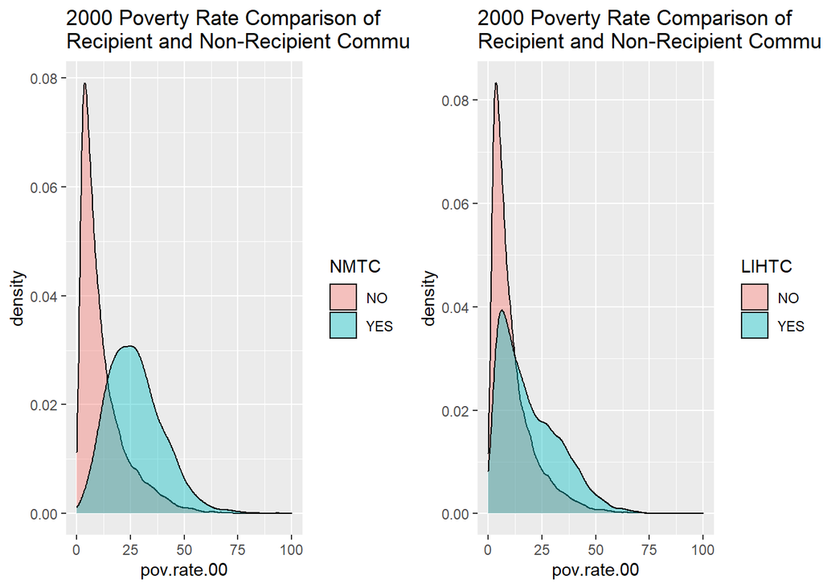

```r
gridExtra::grid.arrange( PLOTS$pov_rate_2000$nmtc,
                         PLOTS$pov_rate_2000$lihtc,
                         nrow = 1 )
```

New Market Tax Credit recipients appear to be quite distinct, located in poorer tracts. We see the LIHTC projects tend to favor tracts with higher poverty than non-recipient tracts, but a large proportion of the projects are still located in tracts with low to moderate levels of poverty.

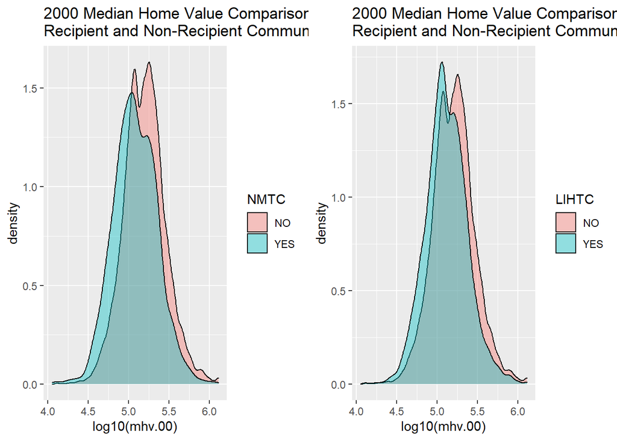

```r
gridExtra::grid.arrange( PLOTS$mhv_2000$nmtc,
                         PLOTS$mhv_2000$lihtc,
                         nrow = 1 )
```

# Evaluating Program Impact

Use the difference-in-difference framework introduced in the tutorial to estimate the impact of each federal program: the NMTC and the LIHTC.

Use your baseline model predicting tract change from Lab 04 as the starting point. Create a log-linear diff-in-diff model following these steps and add your control variables from Lab 04

NMTC data was added to the dataset using the following code found in the data manifest:

```r
### NMTC

# log the variables
#y1 <- log( d$mhv.00 )
#y2 <- log( d$mhv.10 )
#lp.vac.00 <- log10( d$p.vacant.00 + 1)
#lp.vac.10 <- log10( d$p.vacant.10 + 1)
#lp.hs.00 <- log10( d$p.hs.00 + 1)
#p.hs.12 <- log10( d$p.hs.12 + 1)
#lp.unemp.00 <- log10( d$p.unemp.00 + 1)
#lp.unemp.12 <- log10( d$p.unemp.12 + 1)

# create a variable that identifies if a tract received NMTC funding
#nmtc.treat <- as.numeric( d$num.nmtc > 0 )

# store the year 2000 data
#d1 <- data.frame( y=y1, treat=nmtc.treat, post=0 )
# store the year 2010 data
#d2 <- data.frame( y=y2, treat=nmtc.treat, post=1 )

# stack the two time periods together
#d3 <- rbind( d1, d2 )

# controls ---

#p.vac
#d0 <- data.frame( lp.vac.00 = lp.vac.00, lp.vac.10 = lp.vac.10)

#d0 <- d0 %>% tidyr::gather(key = "variable_name",
#value = "p.vac")

# diff-in-diff data
#d3$p.vac <- d0$p.vac


#p.hs
#d0 <- data.frame( lp.hs.00 = lp.hs.00, lp.hs.12 = lp.hs.12)
#d0 <- d0 %>% tidyr::gather(key = "variable-name", value = "p.hs")

# diff-in-diff data
#d3$p.hs <- d0$p.hs


#p.unemp
#d0 <- data.frame( lp.unemp.00 = lp.unemp.00, lp.unemp.12 = lp.unemp.12)
#d0 <- d0 %>% tidyr::gather(key = "variable-name", value = "p.unemp")

# diff-in-diff data
#d3$p.unemp <- d0$p.unemp

#d3 <- d3 %>% na.omit(use = "everything")
```

LIHTC data was added to the dataset with the following code found in the data manifest:

```r
### LIHTC


# variables are already logged
#y1 <- log( d$mhv.00 )
#y2 <- log( d$mhv.10 )
#lp.vac.00 <- log10( d$p.vacant.00)
#lp.vac.10 <- log10( d$p.vacant.10)
#lp.hs.00 <- log10( d$p.hs.00)
#lp.hs.12 <- log10( d$p.hs.12)
#lp.unemp.00 <- log10( d$p.unemp.00)
#lp.unemp.12 <- log10( d$p.unemp.12)

# create a variable that identifies if a tract received LIHTC funding
#lihtc.treat <- as.numeric( d$num.lihtc > 0 )

# store the year 2000 data
#l1 <- data.frame( y=y1, treat=lihtc.treat, post=0 )
# store the year 2010 data
#l2 <- data.frame( y=y2, treat=lihtc.treat, post=1 )

# stack the two time periods together
#l3 <- rbind( l1, l2 )

# controls ---

#p.vac
#l0 <- data.frame( lp.vac.00 = lp.vac.00, lp.vac.10 = lp.vac.10)

#l0 <- l0 %>% tidyr::gather(key = "variable_name",
#value = "p.vac")

# diff-in-diff data
#l3$p.vac <- l0$p.vac


#p.hs
#l0 <- data.frame( lp.hs.00 = lp.hs.00, lp.hs.12 = lp.hs.12)

#l0 <- l0 %>% tidyr::gather(key = "variable_name",
#value = "p.hs")

# diff-in-diff data
#l3$p.hs <- l0$p.hs


#p.unemp
#l0 <- data.frame( lp.unemp.00 = lp.unemp.00, lp.unemp.12 = lp.unemp.12)

#l0 <- l0 %>% tidyr::gather(key = "variable_name",
#value = "p.unemp")

# diff-in-diff data
#l3$p.unemp <- l0$p.unemp

#l3 <- l3 %>% na.omit(use = "everything")
```

# Descriptive Statistics

Let’s take a look at the descriptive statistics for the data:

```r
stargazer::stargazer( df,
                      type=S_TYPE,
                      digits=0,
                      summary.stat = c("min", "p25","median","mean","p75","max") )
```

[output not shown]

#### Change in MHV 2000-2010

If a home worth $10 million increased in value by $100k over ten years it would not be that surprising. If a home worth $50k increased by $100k over the same period that is a growth of 200% and is notable.

The change in value variable only reports absolute change, but does not provide a sense of whether that is a big or small amount for the census tract.

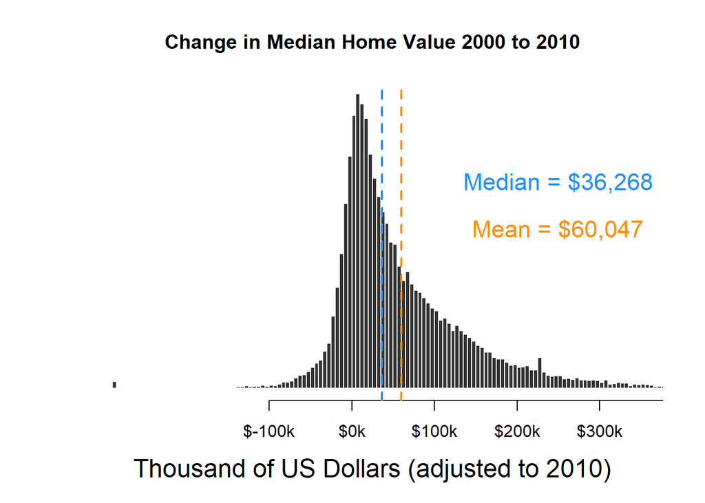

```r
hist( d$mhv.change/1000, breaks=500,
      xlim=c(-300,350), yaxt="n", xaxt="n",
      xlab="Thousand of US Dollars (adjusted to 2010)", cex.lab=1.5,
      ylab="", main="Change in Median Home Value 2000 to 2010",
      col="gray20", border="white" )

axis( side=1, at=seq( from=-100, to=500, by=100 ),
      labels=paste0( "$", seq( from=-100, to=500, by=100 ), "k" ) )

mean.x <- mean( d$mhv.change/1000, na.rm=T )
abline( v=mean.x, col="darkorange", lwd=2, lty=2 )
text( x=250, y=1500,
      labels=paste0( "Mean = ", dollar( round(1000*mean.x,0)) ),
      col="darkorange", cex=1.4, pos=3 )

median.x <- median( d$mhv.change/1000, na.rm=T )
abline( v=median.x, col="dodgerblue", lwd=2, lty=2 )
text( x=250, y=2000,
      labels=paste0( "Median = ", dollar( round(1000*median.x,0)) ),
      col="dodgerblue", cex=1.4, pos=3 )
```

#### Percent Change in MHV 2000 to 2010

The percent change variable provides some context for growth rates of value in census tracts.

Plot the percent change variable:

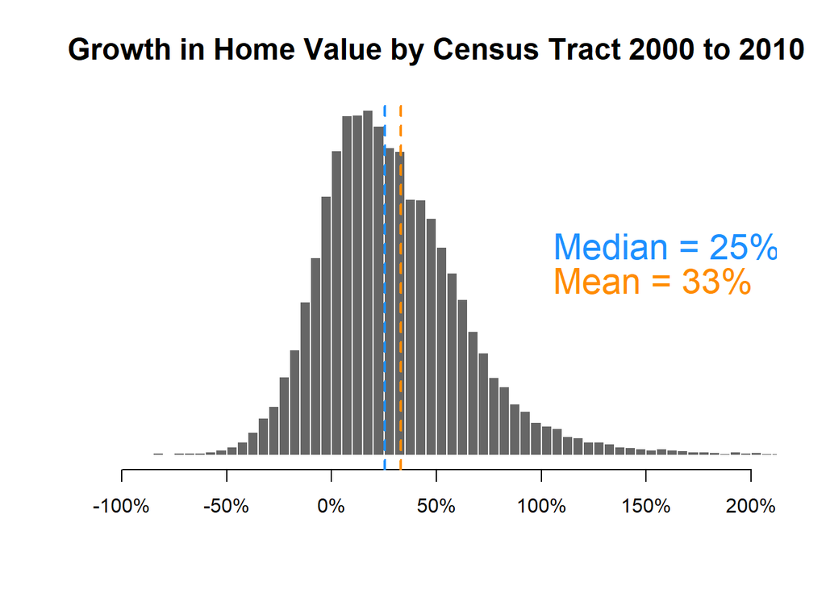

```r
pct.change <- d$mhv.change / d$mhv.00


hg <-
hist( pct.change, breaks=2000,
      xlim=c(-1,2), yaxt="n", xaxt="n",
      xlab="", cex.main=1.5,
      ylab="", main="Growth in Home Value by Census Tract 2000 to 2010",
      col="gray40", border="white" )

axis( side=1, at=seq( from=-1, to=2, by=0.5 ),
      labels=paste0( seq( from=-100, to=200, by=50 ), "%" ) )

ymax <- max( hg$count )

mean.x <- mean( pct.change, na.rm=T )
abline( v=mean.x, col="darkorange", lwd=2, lty=2 )
text( x=1, y=(0.5*ymax),
      labels=paste0( "Mean = ", round(100*mean.x,0), "%"),
      col="darkorange", cex=1.8, pos=4 )

median.x <- median( pct.change, na.rm=T )
abline( v=median.x, col="dodgerblue", lwd=2, lty=2 )
text( x=1, y=(0.6*ymax),
      labels=paste0( "Median = ", round(100*median.x,0), "%"),
      col="dodgerblue", cex=1.8, pos=4 )
```

# Program Participation Criteria

Not all Census tracts are eligible for both programs. The New Market Tax Credit program, in particular, is trying to attract private investment in Census tracts that are considered high-risk because of their current conditions. The tax credits support activities like real-estate projects, small business loans, or building rehab that would traditionally be too expensive or too risky without subsidies (in theory).

The real challenging part about this sort of program is there are some neighborhoods that community developers should not be working in because the investments are not sustainable. You don’t want to incentivize those sorts of investments because they tie up capital in projects that are not sustainable, they raise hopes for the community then let them down, and they waste government resources.

Alternatively, there are tracts that would have been lucrative investments without the tax credits. If there are enough of these (maybe the economy is going through a long period of expansion so investors have extra capital that they need to invest), then all of the program funds might be captured by projects that would have happened without the nudge. The program is just padding the margins for developers, but not catalyzing any new growth.

And then there are the goldilocks cases where the community is a pretty good investment, but not lucrative enough to attract purely private sector actors. The tax credits are just enough to offset some of the risks, and projects will happen that would not have without the program.

If you are too narrow in the qualification criteria you could end up in the first scenario (too many unsustainable investments in unstable communities, thus low impact). If you are too broad you can end up in the second secenario (tax credits supporting investments in stable neighborhoods that would have attracted capital without the program). The best case is a criteria that results in the most grants in the third scenario - sustainable projects that would not have happened without the tax credits.

The fact that private investors have a lot of capital in the projects ensures that they are not simply taking free government money. The tax credits are typically claimed after they spend the money in the community, and thus are invested in projects that they need to be successful to generate a profit. So some incentives are aligned.

The program participation criteria define which census tracts are eligible, and will greatly shape where the program dollars (tax credits) are allocated.

# Report & Interpret

Report and interpret the main results from the models. Are the programs effective at catalyzing neighborhood improvement? We are assuming median home value captures the increased market demand that reflects the desirability of improvements.

### NMTC

```r
# create the difference in difference model
# note: treat = B1, post = B2, treat*post = B3
m <- lm( y ~ treat + post + p.vac + p.hs + p.unemp + treat*post, data=d3, na.rm = TRUE )

# display model results
stargazer::stargazer(m,
                     type = S_TYPE,
                     digits = 2)
```

|  | *Dependent variable:* |
| --- | --- |
|  | y |
| treat | 0.03** |
|  | (0.01) |
| post | 0.51*** |
|  | (0.004) |
| p.vac | -0.78*** |
|  | (0.01) |
| p.hs | 1.65*** |
|  | (0.03) |
| p.unemp | -0.76*** |
|  | (0.01) |
| treat:post | -0.003 |
|  | (0.02) |
| Constant | 10.09*** |
|  | (0.06) |
| Observations | 118,120 |
| R<sup>2</sup> | 0.28 |
| Adjusted R<sup>2</sup> | 0.28 |
| Residual Std. Error | 0.55 (df = 118113) |
| F Statistic | 7,514.34*** (df = 6; 118113) |
| *Note:* | p<0.1; p<0.05; p<0.01 |

Houses, on average, had a 51% increase during the treatment period (2000 - 2010). Although the post-treatment coefficient is different than 1, it is not statistically significant, indicating the NMTC program is not effective.

### LIHTC

```r
# create the difference in difference model
# note: treat = B1, post = B2, treat*post = B3
m <- lm( y ~ treat + post + p.vac + p.hs + p.unemp + treat*post, data=l3 )

# display model results
stargazer::stargazer(m,
                     type = S_TYPE,
                     digits = 2)
```

|  | *Dependent variable:* |
| --- | --- |
|  | y |
| treat | -0.05*** |
|  | (0.01) |
| post | 0.51*** |
|  | (0.004) |
| p.vac | -0.77*** |
|  | (0.01) |
| p.hs | 1.67*** |
|  | (0.03) |
| p.unemp | -0.74*** |
|  | (0.01) |
| treat:post | -0.03*** |
|  | (0.01) |
| Constant | 10.05*** |
|  | (0.06) |
| Observations | 118,120 |
| R<sup>2</sup> | 0.28 |
| Adjusted R<sup>2</sup> | 0.28 |
| Residual Std. Error | 0.55 (df = 118113) |
| F Statistic | 7,562.27*** (df = 6; 118113) |
| *Note:* | p<0.1; p<0.05; p<0.01 |